# Text<>MIDI

```python
!pip install pygame
```

```python
import pygame
```

```python
def play_midi(file_path):
    pygame.mixer.init()
    pygame.mixer.music.load(file_path)
    pygame.mixer.music.play()
```

using pygame to play midi

## MIDI File Structures

```python
play_midi('piano.mid')
```

original file

```python
midi_txt = open("piano.mid", "rb").read()
```

```python
print(midi_txt)
```

```
b"MThd\x00\x00\x00\x06\x00\x00\x00\x01\x00`MTrk\x00\x00\x03\xca\x00\xff\x03\x05piano\x00\xffX\x04\x04\x02$\x08\x00\xffX\x04\x04\x02$\x08\x00\x90'@\x00\x90.G\x00\x903H\x00\x907B\x00\x90?I_\x807@\x01\x80.@\x00\x90.C\x00\x803@\x00\x903H\x00\x9078\x00\x80?@\x00\x90?M_\x80'@)\x807@\x04\x80?@\x04\x803@\x0…
```

### MIDI header chunk

MThd\x00\x00\x00\x06\x00\x00\x00\x01\x00`

#### MThd

header identifier

#### \x00\x00\x00\x06

four bytes indicating the chunk length (in this case 6 bytes)

#### \x00\x00:

MIDI format type, 0 means single-track

#### \x00\x01:

number of tracks (1 track)

#### `\x00`` (0x60 in hex = 96):

ticks per quarter note (timing resolution)

#### MTrk

track chunk identifier

## Manipulating MIDI

### MIDI Encoding

#### MIDI uses a single byte (8 bits) encoding, ranges from 0 to 127, 0x00 to 0x7F in hexadecimal.

#### It follows [Status Byte] [Note Number] [Velocity]. MIDI keyboards usually use 64 as the default or neutral velocity.

#### Note-on: 0x90, Note-off: 0x80

example: 0x90 3C 40 means Note-On, Middle C, Velocity 64.

```python
import random
```

```python
midi_data = bytearray(open("piano.mid", "rb").read())
```

convert to bytearray bytearray: https://www.programiz.com/python-programming/methods/built-in/bytearray

```python
for i in range(len(midi_data) - 2):
    if midi_data[i] in [0x90, 0x80]:  # detect if the note is on or off
        midi_data[i+1] = random.randint(20, 90)  # randomize the pitch
```

```python
with open("modified_piano.mid", "wb") as file:
    file.write(midi_data)
```

write midi data

```python
play_midi("modified_piano.mid")
```

### MIDI to Text

```python
latin_text = open("piano.mid", "r", encoding="latin1").read()
```

```python
print(latin_text)
```

```
MThd`MTrkÊÿpianoÿXÿX'@.G3H7B?I_7@.@.C3@3H78?@?M_'@)7@?@3@3O7P:O?T*.@7@3@:@?@	0Q5F86:E?I`:@&8@80@5@0Q5C8E?@?OX8@0@?@0I:O?SA:@?@5@3M<M?M0@3@3G?@?KY?@3@<@:D<K?J@3P:@:D<@<E?@?RX:@<@?@8E:S<Y?TV>'3@8@<@ :@?@V@.K3@73:I?MC8V;0'AP.@3@7@V@'@:@?@C@'D.J3N7=:M?RCD.@C@7@3@:@3Q7F:QC@RG%7@'@	'</AC@
3@/@
?@:@0P5K8A?KR@RF'@FR@D8@4(70@0O8G?@?MKHW0@8@?@K@(0G8Q?NKM-8@(:(0@5@?@K@3P:\?OKD(@'3@:@3H<J\?@K@3@3Q:O<@<Q?MKL3@:@?@K@+,3D8;:R?UKBR+@8@<@3@:@?@K@3H8A:J<P?JKBc8@\K@3@3B:@:T?@?RKdTK@3@?@:@<@3N8K:R<O?SOd)8@2S<@3@!2@:@'>0S:Z?@?WO@%'0@:@?@ÿ/
```

### MIDI to Image

```python
from PIL import Image, ImageOps, ImageFilter
```

```python
piano_bytes = open("piano.mid", "rb").read()
```

```python
width = 30
padded_text_bytes = piano_bytes + (b' ' * width * 3)
height = int((len(padded_text_bytes) / 3) / width)
```

```python
piano_img = Image.frombytes('RGB', (width, height), padded_text_bytes)
```

```python
def show_scaled(img, scale=20):
    return img.resize((img.width*scale, img.height*scale))
```

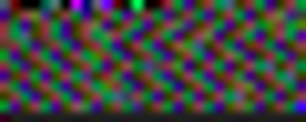

```python
show_scaled(piano_img)
```

```python
modified_piano_bytes = open("modified_piano.mid", "rb").read()
```

```python
width = 30
padded_text_bytes = modified_piano_bytes + (b' ' * width * 3)
height = int((len(padded_text_bytes) / 3) / width)
modified_piano_img = Image.frombytes('RGB', (width, height), padded_text_bytes)
show_scaled(modified_piano_img)
```

[output not shown]

```python
def show_scaled(img, scale=20):
    return img.resize((img.width*scale, img.height*scale))
show_scaled(modified_piano_img)
```

```python
width = 30 # arbitrary, adjust to taste
padded_text_bytes = modified_piano_bytes + (b' ' * width * 3)
height = int((len(padded_text_bytes) / 3) / width)
modified_piano_img = Image.frombytes('RGB', (width, height), padded_text_bytes)
```

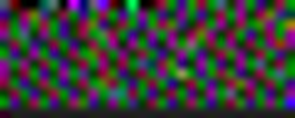

```python
def show_scaled(img, scale=20):
    return img.resize((img.width*scale, img.height*scale))
show_scaled(modified_piano_img)
```

```python
modified_piano_img.save("modified_piano_img.png")
```

## Text to MIDI

```python
text = "hi this is Yifan"
```

```python
filename="output.mid"
```

```python
header_chunk = b"MThd" + b"\x00\x00\x00\x06" + b"\x00\x00" + b"\x00\x01" + b"\x01\xE0"
track_data = b"" #this is a place holder, empty byte string
```

1. header chunk identifier + header chunk size: 6 bytes + MIDI format: single-track file + 1 track + tempo: 480 ticks per quarter note

```python
for char in text:
    midi_note = (ord(char) % 128)
    track_data += b"\x00" + bytes([0x90, midi_note, 64]) #note on
    track_data += b"\x20" + bytes([0x80, midi_note, 64]) #note off
```

2. converts the character to a MIDI note
3. b"\x00" + bytes([0x90, midi_note, 64]) creates a note-on event at velocity 64
4. b"\x20" + bytes([0x80, midi_note, 64]) creates a note-off event after some delay as of \x20

```python
track_data += b"\x00\xFF\x2F\x00"
```

5. add an end mark to the track

```python
track_chunk = b"MTrk" + bytes([
    (len(track_data) >> 24) & 0xFF,
    (len(track_data) >> 16) & 0xFF,
    (len(track_data) >> 8) & 0xFF,
    len(track_data) & 0xFF
]) + track_data
```

7. b"MTrk" is the track chunk identifier
8. parse track data length in 4 bytes
9. get track_data which was stored earlier

The MIDI file format requires the length field to be exactly 4 bytes long (32 bits). Computers store numbers as a sequence of bytes, and MIDI expects this length in big-endian order (most significant byte first). If we only store len(track_data), it would be a single number, not a properly formatted 4-byte field.

```python
with open(filename, "wb") as f:
    f.write(header_chunk + track_chunk)
print("File generated")
```

```
File generated
```

10. add header_chunk and track_chunk together

```python
play_midi("output.mid")
```

```python
text_from_file = open("frost.txt", "r", encoding="utf-8").read()
text = text_from_file.strip()
print(f"Text from file: {text}")
```

```
Text from file: Two roads diverged in a yellow wood
And sorry I could not travel both
And be one traveler long I stood
And looked down one as far as I could
To where it bent in the undergrowth
```

# Takeaway

## patterns of sound <> patterns of text/language